# 1.3

Find the top 5 territories with the most drop in claims volume from year 2017 to 2018 for the variant brand and compare it with that of the competitor brand (Product 3 – J3010).

i. Find the territory-level claims volume per product per year.

ii. Calculate the year-over-year change % for the variant brand between 2017 and 2018.

iii. Sort the territories from smallest to largest value from above.

iv. Take the top 5 territories with the smallest value for year-over-year change % (I.e., biggest drop in claims volume from 2017 - 2018) and extract the claims count for the variant brand and the competitor brand for each year from 2016 – 2018 for these 5 Territories.

v. Expected outputs:

1. A clustered bar chart showing the number of claims from each of these 5 territories for each year from 2016 – 2018 for the variant brand, where one bar is for one Territory within each year and the bars for one year are clustered together.

```python
import pandas as pd

# Load your dataset (adjust the path to your file)
file_path = 'merged_data_meghana.csv'  # Replace with the actual file path if needed
data = pd.read_csv(file_path)

# Convert 'clm_from_dt' to datetime for filtering by year
data['clm_from_dt'] = pd.to_datetime(data['clm_from_dt'], errors='coerce')

data = data[
    (data['clm_from_dt'].dt.year >= 2016) &
    (data['clm_from_dt'].dt.year <= 2018)]

# Extract year from the claim date
data['Year'] = data['clm_from_dt'].dt.year
```

```python
# Filter necessary columns
filtered_data = data[['Year', 'clm_line_hcpcs_cd', 'Territory Name']]

# Count claims by product, year, and territory
claims_volume = filtered_data.groupby(['Year', 'Territory Name', 'clm_line_hcpcs_cd']).size().reset_index(name='Claims')

# Split into Variant Brand and Competitor Brand (J3010)
variant_brand = claims_volume[claims_volume['clm_line_hcpcs_cd'] == 'J2250']
competitor_brand = claims_volume[claims_volume['clm_line_hcpcs_cd'] == 'J3010']
```

```python
# Aggregate duplicate entries by summing claims
variant_brand_aggregated = variant_brand.groupby(['Year', 'Territory Name']).sum(numeric_only=True).reset_index()
competitor_brand_aggregated = competitor_brand.groupby(['Year', 'Territory Name']).sum(numeric_only=True).reset_index()

# Pivot to get year-wise claim volumes per territory
variant_pivot = variant_brand_aggregated.pivot(index='Territory Name', columns='Year', values='Claims').fillna(0)
competitor_pivot = competitor_brand_aggregated.pivot(index='Territory Name', columns='Year', values='Claims').fillna(0)

# Add YoY change % for the variant brand
variant_pivot['YoY_Change_%'] = ((variant_pivot[2018] - variant_pivot[2017]) / variant_pivot[2017]) * 100

# iii. Sort the territories from smallest to largest value of YoY change %
variant_pivot = variant_pivot.sort_values(by="YoY_Change_%")

# Get the top 5 territories with the largest YoY drop
top_5_territories = variant_pivot.nsmallest(5, 'YoY_Change_%').index.tolist()
```

```python
# Filter claims for these territories
top_5_variant = variant_brand_aggregated[variant_brand_aggregated['Territory Name'].isin(top_5_territories)]
top_5_competitor = competitor_brand_aggregated[competitor_brand_aggregated['Territory Name'].isin(top_5_territories)]

# Pivot for visualization
top_5_variant_pivot = top_5_variant.pivot(index='Year', columns='Territory Name', values='Claims').fillna(0)
top_5_competitor_pivot = top_5_competitor.pivot(index='Year', columns='Territory Name', values='Claims').fillna(0)
```

```python
print(top_5_variant_pivot)
print(top_5_competitor_pivot)
```

```
Territory Name  LA-San Diego, CA  Minneapolis, MN  New York, NY  Phoenix, AZ  \
Year
2016                          29               15            24           11
2017                          38               15            40           10
2018                          16                7            17            3

Territory Name  St Louis, MO
Year
2016                      19
2017                      22
2018                       6
Territory Name  LA-San Diego, CA  Minneapolis, MN  New York, NY  Phoenix, AZ  \
Year
2016                          55               14            33            7
2017                          86               37            81           23
2018                          99               50           153           32

Territory Name  St Louis, MO
Year
2016                      23
2017                      40
2018                      54
```

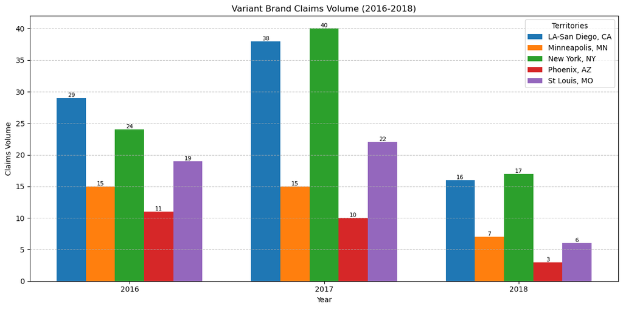

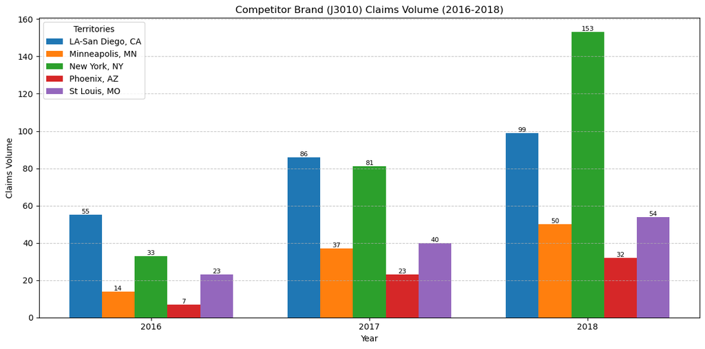

```python
# Define a function to create clustered bar charts with values
def create_clustered_bar_chart(data, title, ylabel, colors):
    years = data.index.astype(int)  # Ensure years are integers for labeling
    territories = data.columns
    x = np.arange(len(years))  # x locations for the groups
    width = 0.15  # bar width

    # Initialize the plot
    fig, ax = plt.subplots(figsize=(12, 6))
    for i, territory in enumerate(territories):
        bars = ax.bar(x + i * width, data[territory], width, label=territory, color=colors[i])

        # Add values on top of each bar
        for bar in bars:
            height = bar.get_height()
            ax.text(bar.get_x() + bar.get_width() / 2, height, f'{int(height)}',
                    ha='center', va='bottom', fontsize=8)

    # Customize the plot
    ax.set_xlabel('Year')
    ax.set_ylabel(ylabel)
    ax.set_title(title)
    ax.set_xticks(x + (len(territories) - 1) * width / 2)
    ax.set_xticklabels(years)
    ax.legend(title="Territories")
    plt.grid(axis='y', linestyle='--', alpha=0.7)
    plt.tight_layout()

    return fig, ax

# Colors for the territories
territory_colors = ['#1f77b4', '#ff7f0e', '#2ca02c', '#d62728', '#9467bd']

# Generate bar charts for both the Variant Brand and Competitor Brand
fig1, ax1 = create_clustered_bar_chart(
    top_5_variant_pivot,
    title='Variant Brand Claims Volume (2016-2018)',
    ylabel='Claims Volume',
    colors=territory_colors
)
fig2, ax2 = create_clustered_bar_chart(
    top_5_competitor_pivot,
    title='Competitor Brand (J3010) Claims Volume (2016-2018)',
    ylabel='Claims Volume',
    colors=territory_colors
)

plt.show()
```

### Observations from the Charts

#### **Competitor Brand (J3010)**

1. **Steady Growth**:
   - Unlike the variant brand, **Product 3 (J3010)** shows consistent growth in claims volume from 2016 to 2018 in all territories.
   - The claims volume in **New York, NY** and **LA-San Diego, CA** is particularly high in 2018, signaling strong adoption by HCPs in these regions.
2. **Territory Variance**:
   - **Phoenix, AZ** has a relatively small market for Product 3 but still exhibits growth, contrasting the variant brand's decline.

### Recommendations**

#### **1. Aggressive HCP Engagement**

- **Focus on High-Volume HCPs in Declining Territories**:
  - Identify HCPs with high prescribing volumes of Product 3 in the declining territories (e.g., Minneapolis, Phoenix) and target them with tailored campaigns to **convert them back to Product 2**.
  - Provide **financial incentives** (rebates, discounts, or bonuses) for HCPs to prescribe Product 2 instead of Product 3.
- **Target Key Opinion Leaders (KOLs)**:
  - Partner with influential HCPs in highly populated territories like LA-San Diego and New York to advocate for Product 2.
  - Conduct KOL-led seminars and webinars demonstrating the effectiveness and advantages of Product 2.
- **Clinical Education Campaigns**:
  - Highlight any **unique benefits of Product 2**, such as better patient outcomes, faster recovery, or lower side effects, compared to Product 3.
  - Use real-world evidence and comparative studies to **differentiate Product 2** from competitors.

#### **2. Increase Claims Volume through Strategic Incentives**

- **Introduce Territory-Specific Pricing Models**:
  - Implement **dynamic pricing strategies** for Product 2 in territories with declining claims. Lower prices temporarily to attract new claims and regain market share.
- **Volume-Based Rewards**:
  - Roll out programs where HCPs receive bonuses or rebates for increasing their claims volume for Product 2.
  - Offer free trials or heavily discounted initial doses to incentivize HCPs to prescribe Product 2.
- **Exclusive Hospital Partnerships**:
  - Partner with major hospital networks in high-priority territories to make Product 2 the **default anesthetic option** for relevant procedures.

#### **4. Improve Patient-Centric Marketing**

- **Focus on Patient Benefits**:
  - If Product 2 has any advantages such as reduced side effects, shorter sedation times, or faster recovery, promote these benefits to both HCPs and patients.
  - Collaborate with hospitals to promote Product 2 as part of pre-surgical patient education materials.
- **Expand Use Cases**:
  - Work with HCPs to increase Product 2 prescriptions for a wider variety of procedures or patient demographics, such as pediatrics or geriatrics.

#### **5. Focused Initiatives in Top 5 Territories**

- **Highly Populated Territories (e.g., LA-San Diego, New York)**:
  - Invest in **localized sales teams** and marketing campaigns that are specifically tailored to the needs of these regions.
  - Offer **territory-specific loyalty programs** to incentivize HCPs in these areas.
- **Less Populated Territories (e.g., Minneapolis, Phoenix)**:
  - Focus on **educating smaller HCP networks** about Product 2’s advantages.
  - Bundle Product 2 with other related products to improve its adoption.

#### **6. Long-Term Innovation**

- **Develop Next-Generation Differentiation**:
  - Start R&D efforts to improve Product 2’s formulation or delivery mechanism to directly challenge Product 3’s advantages.
  - Announce ongoing innovation efforts to signal the brand’s commitment to staying competitive.

### Expected Outcomes

By implementing these strategies:

1. **Increase HCP Prescriptions**: Aggressive incentives and targeted campaigns will lead to higher claims volume for Product 2.
2. **Expand Market Share**: Competitive pricing, improved education, and patient-centric marketing will drive adoption in declining and high-growth territories.
3. **Counter Product 3**: Directly addressing Product 3’s growth will stabilize Product 2 and position it as a viable alternative.